# Topic Modelling

Saumya Mehta

5/15/2018

Latent Dirichlet Allocation (LDA) is a particularly popular method for fitting a topic model. It treats each document as a mixture of topics and each topic as a mixture of words. This allows documents to overlap each other in terms of content rather than being separated in discrete groups.

## LDA (Latent Dirichlet Allocation)

```r
library(topicmodels)
data("AssociatedPress")

AssociatedPress
```

```
## <<DocumentTermMatrix (documents: 2246, terms: 10473)>>
## Non-/sparse entries: 302031/23220327
## Sparsity           : 99%
## Maximal term length: 18
## Weighting          : term frequency (tf)
```

Creating a two topic model

```r
ap_lda <- LDA(AssociatedPress, k = 2, control = list(seed = 1234))

ap_lda
```

```
## A LDA_VEM topic model with 2 topics.
```

## Word topic probabilities

Tidytext provides this method for extracting the per topic per word probabilities called $β$ from the model.

```r
library(tidytext)
ap_topics <- tidy(ap_lda, matrix = "beta")

ap_topics
```

```
## # A tibble: 20,946 x 3
##    topic term           beta
##    <int> <chr>         <dbl>
##  1     1 aaron      1.69e-12
##  2     2 aaron      3.90e- 5
##  3     1 abandon    2.65e- 5
##  4     2 abandon    3.99e- 5
##  5     1 abandoned  1.39e- 4
##  6     2 abandoned  5.88e- 5
##  7     1 abandoning 2.45e-33
##  8     2 abandoning 2.34e- 5
##  9     1 abbott     2.13e- 6
## 10     2 abbott     2.97e- 5
## # ... with 20,936 more rows
```

This has converted the model into one topic per term per row format. For each combination, the model computes the probability of the term being generated from that topic.

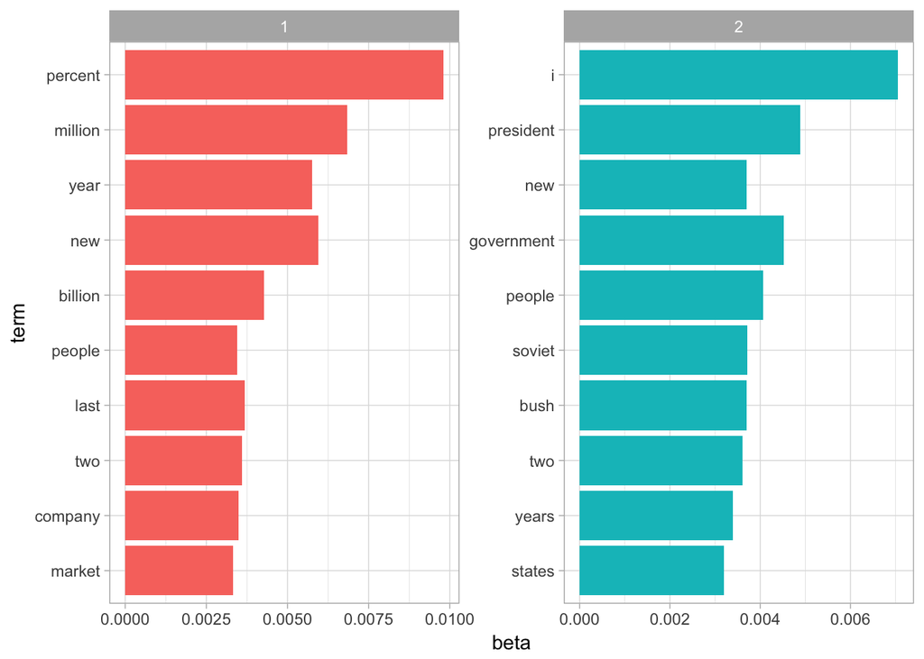

Figure 6.1: The terms that are most common within each topic

```r
library(tidyr)
beta_spread <- ap_topics %>%
  mutate(topic = paste0("topic",topic)) %>%
  spread(topic,beta) %>%
  filter(topic1 > .001 | topic2 > .001) %>%
  mutate(log_ratio = log2(topic2/topic1))

beta_spread
```

```
## # A tibble: 198 x 4
##    term              topic1      topic2 log_ratio
##    <chr>              <dbl>       <dbl>     <dbl>
##  1 administration 0.000431  0.00138         1.68
##  2 ago            0.00107   0.000842       -0.339
##  3 agreement      0.000671  0.00104         0.630
##  4 aid            0.0000476 0.00105         4.46
##  5 air            0.00214   0.000297       -2.85
##  6 american       0.00203   0.00168        -0.270
##  7 analysts       0.00109   0.000000578   -10.9
##  8 area           0.00137   0.000231       -2.57
##  9 army           0.000262  0.00105         2.00
## 10 asked          0.000189  0.00156         3.05
## # ... with 188 more rows
```

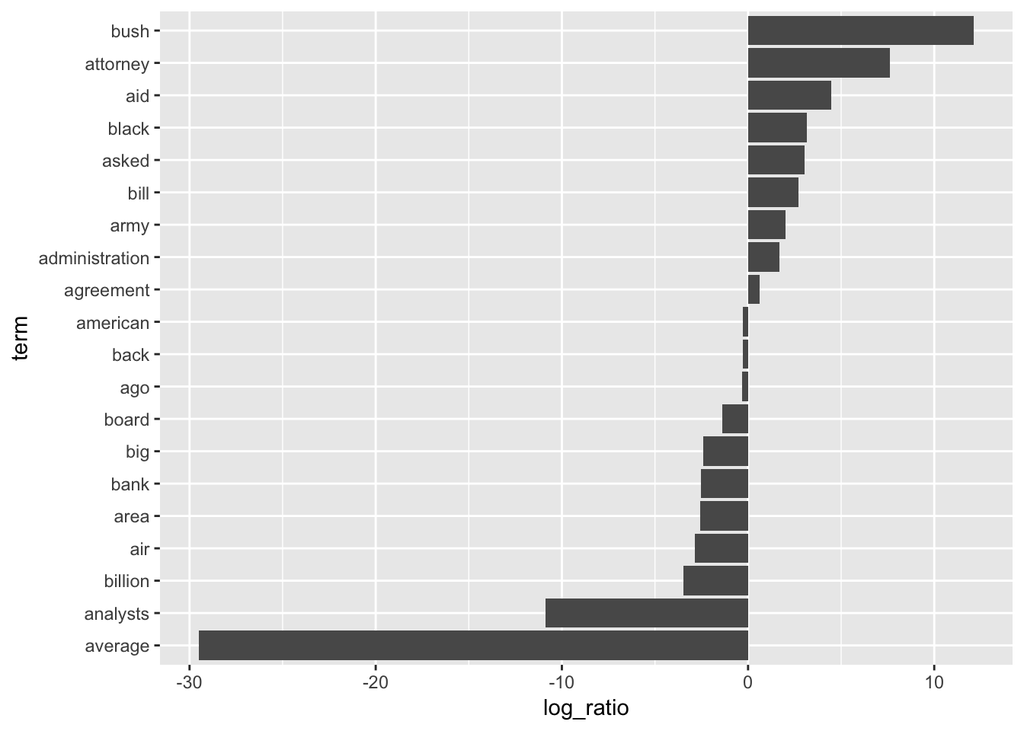

## Document topic probabilities

Besides estimating each topic as a mixture of words, LDA also models each document as a mixture of topics. We can examine the per-document-per-topic probabilities, called  
γ (“gamma”), with the matrix = “gamma” argument to tidy().

```r
ap_documents <- tidy(ap_lda, matrix = "gamma")

ap_documents
```

```
## # A tibble: 4,492 x 3
##    document topic    gamma
##       <int> <int>    <dbl>
##  1        1     1 0.248
##  2        2     1 0.362
##  3        3     1 0.527
##  4        4     1 0.357
##  5        5     1 0.181
##  6        6     1 0.000588
##  7        7     1 0.773
##  8        8     1 0.00445
##  9        9     1 0.967
## 10       10     1 0.147
## # ... with 4,482 more rows
```

```r
tidy(AssociatedPress) %>%
  filter(document == 6) %>%
  arrange(desc(count))
```

```
## # A tibble: 287 x 3
##    document term           count
##       <int> <chr>          <dbl>
##  1        6 noriega          16.
##  2        6 panama           12.
##  3        6 jackson           6.
##  4        6 powell            6.
##  5        6 administration    5.
##  6        6 economic          5.
##  7        6 general           5.
##  8        6 i                 5.
##  9        6 panamanian        5.
## 10        6 american          4.
## # ... with 277 more rows
```

## Example: The great library heist

```r
titles <- c("Twenty Thousand Leagues under the Sea", "The War of the Worlds",
            "Pride and Prejudice", "Great Expectations")

library(gutenbergr)
books <- gutenberg_works(title %in% titles) %>%
  gutenberg_download(meta_fields = "title")
```

```
## Determining mirror for Project Gutenberg from http://www.gutenberg.org/robot/harvest
```

```
## Using mirror http://aleph.gutenberg.org
```

Divide documents into chapters, split into words and find doc-word counts

```r
library(stringr)
# chapters from documents

by_chapter <- books %>%
  group_by(title) %>%
  mutate(chapter = cumsum(str_detect(text, regex("^chapter ",ignore_case = T)))) %>%
  ungroup() %>%
  filter(chapter > 0) %>%
  unite(document, title, chapter)

# split into words
by_chapter_word <- by_chapter %>%
  unnest_tokens(word, text)

# find document-word counts
word_counts <- by_chapter_word %>%
  anti_join(stop_words) %>%
  count(document, word, sort = TRUE) %>%
  ungroup()
word_counts
```

```
## # A tibble: 104,722 x 3
##    document                 word        n
##    <chr>                    <chr>   <int>
##  1 Great Expectations_57    joe        88
##  2 Great Expectations_7     joe        70
##  3 Great Expectations_17    biddy      63
##  4 Great Expectations_27    joe        58
##  5 Great Expectations_38    estella    58
##  6 Great Expectations_2     joe        56
##  7 Great Expectations_23    pocket     53
##  8 Great Expectations_15    joe        50
##  9 Great Expectations_18    joe        50
## 10 The War of the Worlds_16 brother    50
## # ... with 104,712 more rows
```

## LDA on chapters

```r
chapters_dtm <- word_counts %>%
  cast_dtm(document,word,n)

chapters_dtm
```

```
## <<DocumentTermMatrix (documents: 193, terms: 18215)>>
## Non-/sparse entries: 104722/3410773
## Sparsity           : 97%
## Maximal term length: 19
## Weighting          : term frequency (tf)
```

We can use the LDA function to create four-topic model. 4 topics because of 4 books.

```r
chapters_lda <- LDA(chapters_dtm, k = 4, control = list(seed = 1234))
chapters_lda
```

```
## A LDA_VEM topic model with 4 topics.
```

Now we can examine the per topic per word probability.

```r
chapter_topics <- tidy(chapters_lda, matrix = "beta")

chapter_topics
```

```
## # A tibble: 72,860 x 3
##    topic term        beta
##    <int> <chr>      <dbl>
##  1     1 joe     1.44e-17
##  2     2 joe     5.96e-61
##  3     3 joe     9.88e-25
##  4     4 joe     1.45e- 2
##  5     1 biddy   5.14e-28
##  6     2 biddy   5.02e-73
##  7     3 biddy   4.31e-48
##  8     4 biddy   4.78e- 3
##  9     1 estella 2.43e- 6
## 10     2 estella 4.32e-68
## # ... with 72,850 more rows
```

This has turned the model into one topic per term per row format. For each combination, the model computes the probability that term is being generated from that topic. We can now find the top 5 terms in each topic.

```r
top_terms <- chapter_topics %>%
  group_by(topic) %>%
  top_n(5, beta) %>%
  ungroup() %>%
  arrange(topic, -beta)

top_terms
```

```
## # A tibble: 20 x 3
##    topic term         beta
##    <int> <chr>       <dbl>
##  1     1 elizabeth 0.0141
##  2     1 darcy     0.00881
##  3     1 miss      0.00871
##  4     1 bennet    0.00694
##  5     1 jane      0.00649
##  6     2 captain   0.0155
##  7     2 nautilus  0.0131
##  8     2 sea       0.00884
##  9     2 nemo      0.00871
## 10     2 ned       0.00803
## 11     3 people    0.00679
## 12     3 martians  0.00646
## 13     3 time      0.00534
## 14     3 black     0.00528
## 15     3 night     0.00449
## 16     4 joe       0.0145
## 17     4 time      0.00685
## 18     4 pip       0.00683
## 19     4 looked    0.00637
## 20     4 miss      0.00623
```

Visualizing terms that are most common within each topic.

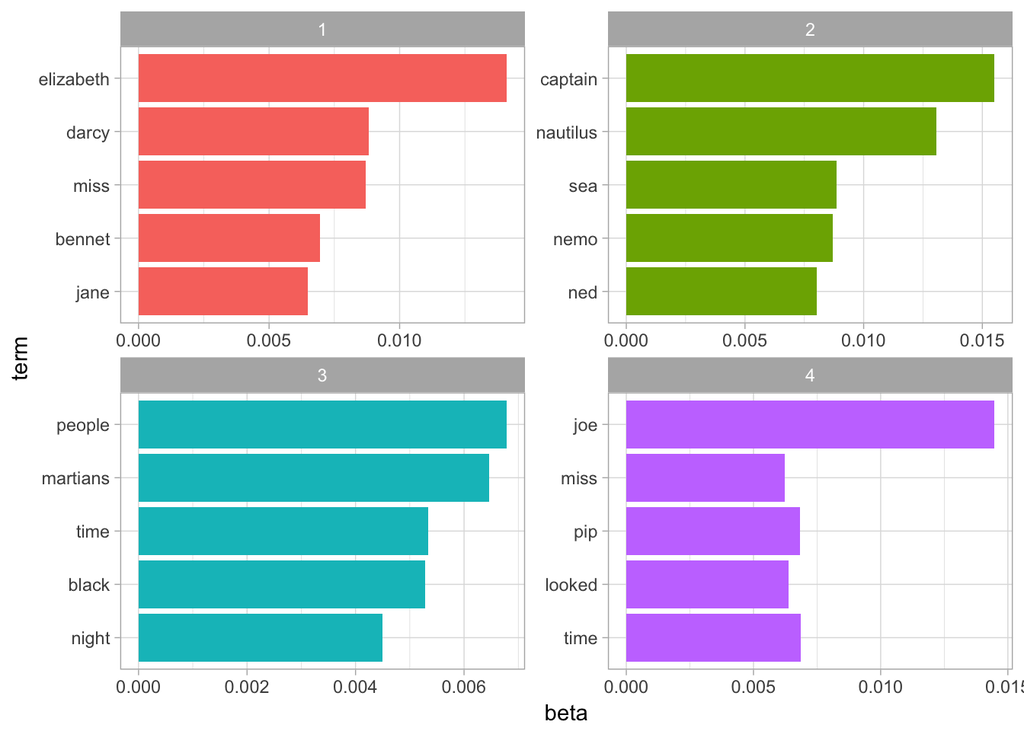

Figure 6.3: The terms that are most common within each topic

## Per document classification

We find out which topics belong to which chapters. We can find this by examining per document per topic probabilities $γ$.

```r
chapters_gamma <- tidy(chapters_lda, matrix = "gamma")

chapters_gamma
```

```
## # A tibble: 772 x 3
##    document                 topic     gamma
##    <chr>                    <int>     <dbl>
##  1 Great Expectations_57        1 0.0000134
##  2 Great Expectations_7         1 0.0000146
##  3 Great Expectations_17        1 0.0000210
##  4 Great Expectations_27        1 0.0000190
##  5 Great Expectations_38        1 0.355
##  6 Great Expectations_2         1 0.0000171
##  7 Great Expectations_23        1 0.547
##  8 Great Expectations_15        1 0.0124
##  9 Great Expectations_18        1 0.0000126
## 10 The War of the Worlds_16     1 0.0000107
## # ... with 762 more rows
```

Now we can separate the document name into title and chapter and then we can visualize the per document per topic probability.

```r
chapters_gamma <- chapters_gamma %>%
   separate(document, c("title", "chapter"),sep = "_", convert = T)

chapters_gamma
```

```
## # A tibble: 772 x 4
##    title                 chapter topic     gamma
##    <chr>                   <int> <int>     <dbl>
##  1 Great Expectations         57     1 0.0000134
##  2 Great Expectations          7     1 0.0000146
##  3 Great Expectations         17     1 0.0000210
##  4 Great Expectations         27     1 0.0000190
##  5 Great Expectations         38     1 0.355
##  6 Great Expectations          2     1 0.0000171
##  7 Great Expectations         23     1 0.547
##  8 Great Expectations         15     1 0.0124
##  9 Great Expectations         18     1 0.0000126
## 10 The War of the Worlds      16     1 0.0000107
## # ... with 762 more rows
```

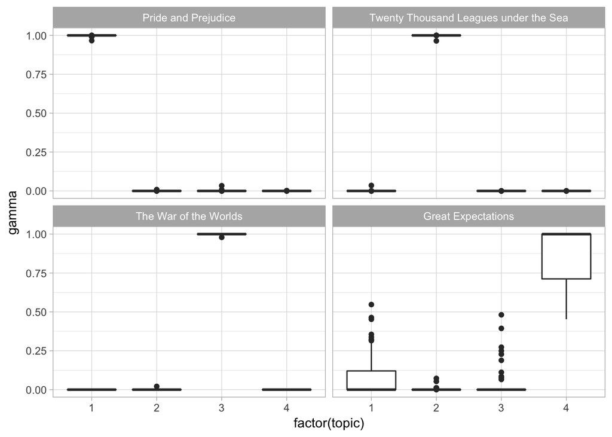

Figure 6.4: The gamma probabilities for each chapter within each book

Now we can find the topic that is most associated with the chapter using top_n()

```r
chapters_classification <- chapters_gamma %>%
  group_by(title, chapter) %>%
  top_n(1, gamma) %>%
  ungroup()

chapters_classification
```

```
## # A tibble: 193 x 4
##    title               chapter topic gamma
##    <chr>                 <int> <int> <dbl>
##  1 Great Expectations       23     1 0.547
##  2 Pride and Prejudice      43     1 1.000
##  3 Pride and Prejudice      18     1 1.000
##  4 Pride and Prejudice      45     1 1.000
##  5 Pride and Prejudice      16     1 1.000
##  6 Pride and Prejudice      29     1 1.000
##  7 Pride and Prejudice      10     1 1.000
##  8 Pride and Prejudice       8     1 1.000
##  9 Pride and Prejudice      56     1 1.000
## 10 Pride and Prejudice      47     1 1.000
## # ... with 183 more rows
```

We can now compare the consensus topic for each book and see which one is the most misidentified.

```r
book_topics <- chapters_classification %>%
  count(title,topic) %>%
  group_by(title) %>%
  top_n(1,n) %>%
  ungroup() %>%
  transmute(consensus = title, topic)

chapters_classification %>%
  inner_join(book_topics, by = "topic") %>%
  filter(title != consensus)
```

```
## # A tibble: 2 x 5
##   title              chapter topic gamma consensus
##   <chr>                <int> <int> <dbl> <chr>
## 1 Great Expectations      23     1 0.547 Pride and Prejudice
## 2 Great Expectations      54     3 0.481 The War of the Worlds
```

We can see that only two chapters from Great Expectation are misclassified.

## By words assignment : argument

One step of the LDA algorithm is assigning each word in each document to a topic. The more words in a document are assigned to that topic, generally, the more weight (gamma) will go on that document-topic classification.  
We may want to see which words from original document-word pair were assigned to which topic. This can be done using augment() function from broom package used to tidy modell output. While tidy() retrieves the statistical components of the model, augment() uses a model to add information to each observation in the original data.

```r
assignments <- augment(chapters_lda, data = chapters_dtm)

assignments
```

```
## # A tibble: 104,722 x 4
##    document              term  count .topic
##    <chr>                 <chr> <dbl>  <dbl>
##  1 Great Expectations_57 joe     88.     4.
##  2 Great Expectations_7  joe     70.     4.
##  3 Great Expectations_17 joe      5.     4.
##  4 Great Expectations_27 joe     58.     4.
##  5 Great Expectations_2  joe     56.     4.
##  6 Great Expectations_23 joe      1.     4.
##  7 Great Expectations_15 joe     50.     4.
##  8 Great Expectations_18 joe     50.     4.
##  9 Great Expectations_9  joe     44.     4.
## 10 Great Expectations_13 joe     40.     4.
## # ... with 104,712 more rows
```

We can compare the assessments table to consensus to find out which were incorrectly classified.

```r
assignments <- assignments %>%
  separate(document, c("title","chapter"), sep = "_", convert = T) %>%
  inner_join(book_topics, by = c(".topic" = "topic"))

assignments
```

```
## # A tibble: 104,722 x 6
##    title              chapter term  count .topic consensus
##    <chr>                <int> <chr> <dbl>  <dbl> <chr>
##  1 Great Expectations      57 joe     88.     4. Great Expectations
##  2 Great Expectations       7 joe     70.     4. Great Expectations
##  3 Great Expectations      17 joe      5.     4. Great Expectations
##  4 Great Expectations      27 joe     58.     4. Great Expectations
##  5 Great Expectations       2 joe     56.     4. Great Expectations
##  6 Great Expectations      23 joe      1.     4. Great Expectations
##  7 Great Expectations      15 joe     50.     4. Great Expectations
##  8 Great Expectations      18 joe     50.     4. Great Expectations
##  9 Great Expectations       9 joe     44.     4. Great Expectations
## 10 Great Expectations      13 joe     40.     4. Great Expectations
## # ... with 104,712 more rows
```

We can visualize a confusion matrix showing how often words from one book were assigned to other book using dplyr’s count and ggplot2’s geom_tile.

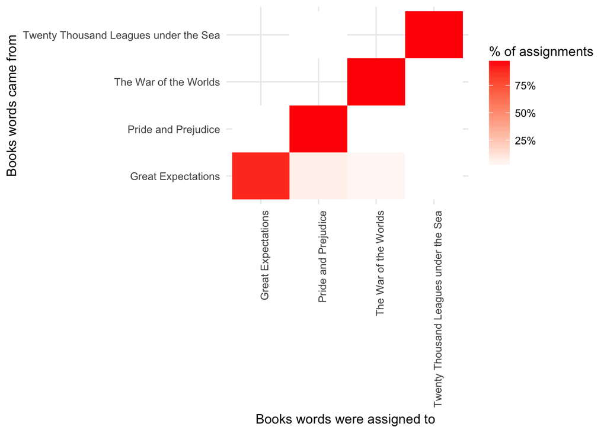

Figure 6.5: Confusion matrix showing where LDA assigned the words from each book. Each row of this table represents the true book each word came from, and each column represents what book it was assigned to

We notice that almost all the words for Pride and Prejudice, Twenty Thousand Leagues Under the Sea, and War of the Worlds were correctly assigned, while Great Expectations had a fair number of misassigned words.

What were the most commonly mistaken words ?

```r
wrong_words <- assignments %>%
  filter(title != consensus)

wrong_words %>%
  count(title, consensus,term, wt = count) %>%
  ungroup() %>%
  arrange(desc(n))
```

```
## # A tibble: 3,551 x 4
##    title              consensus             term         n
##    <chr>              <chr>                 <chr>    <dbl>
##  1 Great Expectations Pride and Prejudice   love       44.
##  2 Great Expectations Pride and Prejudice   sergeant   37.
##  3 Great Expectations Pride and Prejudice   lady       32.
##  4 Great Expectations Pride and Prejudice   miss       26.
##  5 Great Expectations The War of the Worlds boat       25.
##  6 Great Expectations The War of the Worlds tide       20.
##  7 Great Expectations The War of the Worlds water      20.
##  8 Great Expectations Pride and Prejudice   father     19.
##  9 Great Expectations Pride and Prejudice   baby       18.
## 10 Great Expectations Pride and Prejudice   flopson    18.
## # ... with 3,541 more rows
```

```r
word_counts %>%
  filter(word == "flopson")
```

```
## # A tibble: 3 x 3
##   document              word        n
##   <chr>                 <chr>   <int>
## 1 Great Expectations_22 flopson    10
## 2 Great Expectations_23 flopson     7
## 3 Great Expectations_33 flopson     1
```

The LDA algorithm is stochastic, and it can accidentally land on a topic that spans multiple books.

## Alternative LDA implementations.

mallet implements a wrapper around MALLET java package and tidytext provides tidiers for this model output as well.  
It takes non tokenized documents and performs tokenization itself and requires a separate file for stop words. This means we have to collapse the text into one string for each document before performing LDA.

```r
library(mallet)
# create a vector with one string per chapter
collapsed <- by_chapter_word %>%
  anti_join(stop_words, by = "word") %>%
  mutate(word = str_replace(word, "'","")) %>%
  group_by(document) %>%
  summarise(text = paste(word, collapse = " "))

# create an empty file of stop words.
file.create(empty_file <- tempfile())
```

```
## [1] TRUE
```

```r
docs <- mallet.import(collapsed$document, collapsed$text, empty_file)

mallet_model <- MalletLDA(num.topics = 4)
mallet_model$loadDocuments(docs)
mallet_model$train(100)
```

After creating and training the model, we can use the tidy() and augment() functions in the same way as in LDA()

```r
# topic word pairs
tidy(mallet_model)
```

```
## # A tibble: 71,064 x 3
##    topic term           beta
##    <int> <chr>         <dbl>
##  1     1 chapter 0.000000318
##  2     2 chapter 0.00126
##  3     3 chapter 0.00441
##  4     4 chapter 0.000000212
##  5     1 fathers 0.000000318
##  6     2 fathers 0.000000225
##  7     3 fathers 0.000000308
##  8     4 fathers 0.000722
##  9     1 family  0.000000318
## 10     2 family  0.000000225
## # ... with 71,054 more rows
```

```r
# document-topic pairs
tidy(mallet_model, matrix = "gamma")
```

```
## # A tibble: 772 x 3
##    document              topic  gamma
##    <chr>                 <int>  <dbl>
##  1 Great Expectations_1      1 0.158
##  2 Great Expectations_10     1 0.0706
##  3 Great Expectations_11     1 0.0860
##  4 Great Expectations_12     1 0.0928
##  5 Great Expectations_13     1 0.0576
##  6 Great Expectations_14     1 0.108
##  7 Great Expectations_15     1 0.0827
##  8 Great Expectations_16     1 0.0867
##  9 Great Expectations_17     1 0.0587
## 10 Great Expectations_18     1 0.0387
## # ... with 762 more rows
```

```r
# column needs to be named "term" for "augment"

term_counts <- rename(word_counts, term = word)
augment(mallet_model, term_counts)
```

```
## # A tibble: 104,722 x 4
##    document                 term        n .topic
##    <chr>                    <chr>   <int>  <int>
##  1 Great Expectations_57    joe        88      2
##  2 Great Expectations_7     joe        70      2
##  3 Great Expectations_17    biddy      63      2
##  4 Great Expectations_27    joe        58      2
##  5 Great Expectations_38    estella    58      2
##  6 Great Expectations_2     joe        56      2
##  7 Great Expectations_23    pocket     53      2
##  8 Great Expectations_15    joe        50      2
##  9 Great Expectations_18    joe        50      2
## 10 The War of the Worlds_16 brother    50      2
## # ... with 104,712 more rows
```